# Лабораторная работа 1

Бабикова Евгения

28 09 2017

# Исходные данные

Экспоненциальное распределение определяется следующей функцией распределения:

```
F(x) = 1 - e^(-λ⋅x)
```

Функция `rexp` генерирует случайные переменные при помощи экспоненциального распределения `rexp(n=42, rate=5)` вернёт 42 экспоненциально-распределённых числа с параметром (λ) равным 5. Если второй аргумент не указан, будет использовано значение 1, т.е. получим “стандартное экспоненциальное распределение”.

# Задание 1

1. Вектор *exp.1* состоит из 200 случайных значений из стандартного экспоненциального распределения.

Среднее и стандартное отклонение из данных вектора *exp.1*.

```
## [1] 0.9750414
```

```
## [1] 0.9297731
```

2. С использованием значений параметра λ: 0.1, 0.5, 5, 10 получены векторы *exp.0.1*, *exp.0.5*, *exp.5*, *exp.10*.
3. Функция `plot()` общая функция для визуализации данных. Функция `hist()` принимает данные и раскладывает их по корзинам. Чтобы использовать эти функции нужно для начала передать им данные, которые хотим визуализировать.
4. Построена гистограмма полученного выше стандартного распределения.

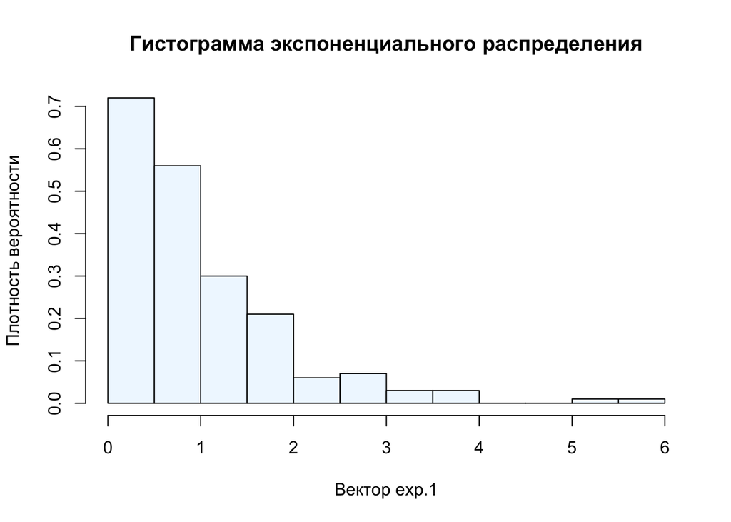

5. Построен график значений того же вектора в порядке следования.

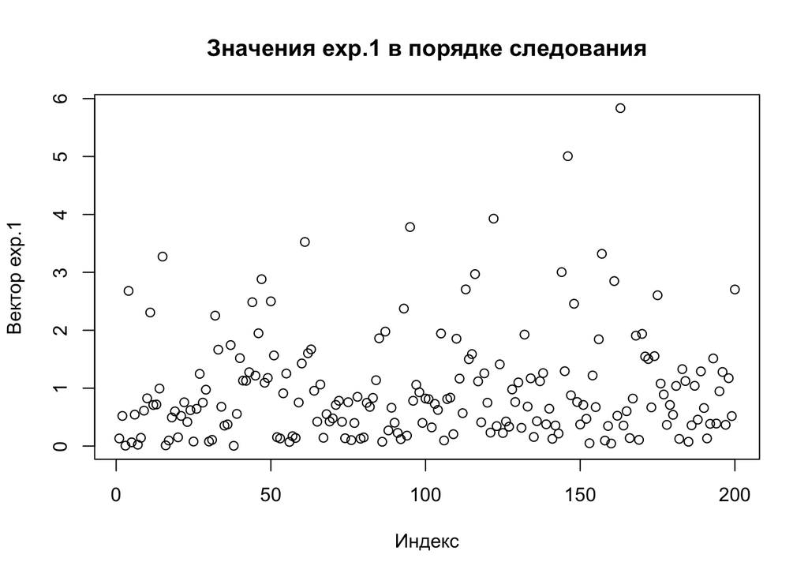

6. Получена диаграмма рассеяния ([scatterplot](https://www.mathsisfun.com/data/scatter-xy-plots.html)) векторов *exp.0.1* и *exp.10* относительно друг друга.

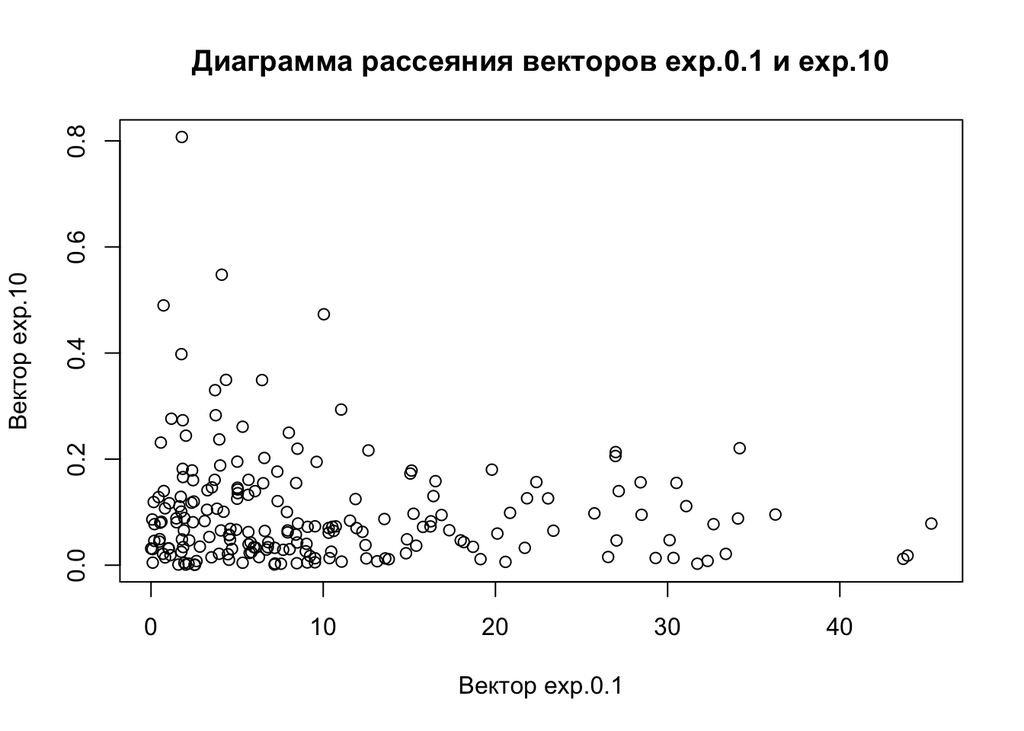

7. Создан вектор *exp.means*, содержащий средние значения каждого из 5 полученных ранее распределений в порядке их создания.

```
## [1]  0.97504136 10.00817008  1.89789033  0.19675137  0.09830381
```

8. Получена диаграмма рассеяния вектора *exp.means* и вектора, содержащего значения λ.

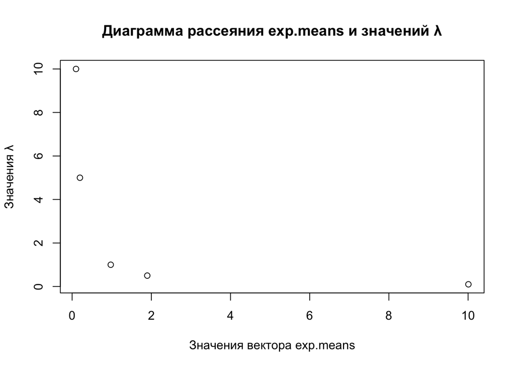

9. Диаграмма рассеяния вектора со значениями стандартных отклонений и вектора, содержащего значения λ, приведена ниже.

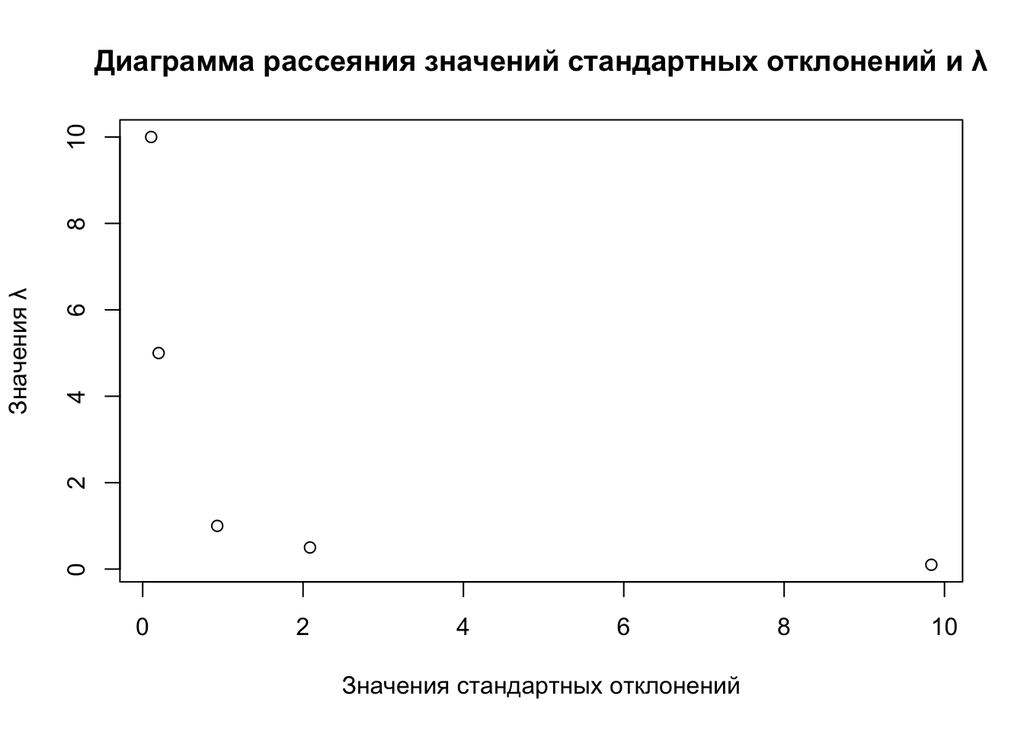

10. Построена диаграмма рассеяния векторов *exp.means* и *exp.sds*.

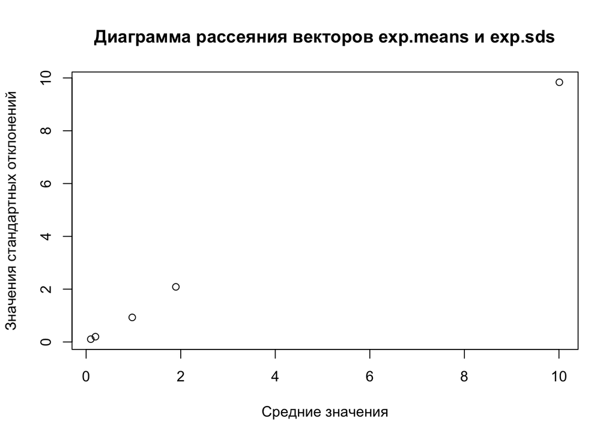

# Задание 2

1. Сгенирировано 1100000 (1 млн. 100 тысяч) чисел из стандартного экспоненциального распределения в вектор *huge.exp.1*. Получено среднее и стандартное отклонение.

```
## [1] 0.998985
```

```
## [1] 0.9988128
```

2. Получена гистограмма *huge.exp.1*.

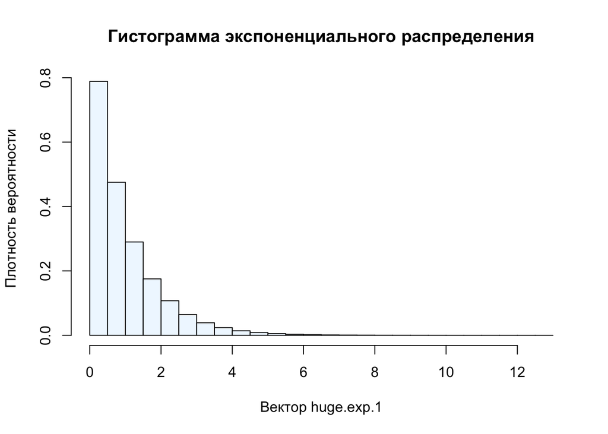

Полученная гистограмма не соответствует функции 1 - e:^(-x), так как формула стандартного экспоненциального распределения: e^(-x), которой и соответствует полученная гистограмма.

```
## [1] 0.3679327
```

4. Получена матрица *huge.exp.1.mat*, содержащая 1100 строк и 1000 колонок.

Построена гистограмма с полученной матрицей.

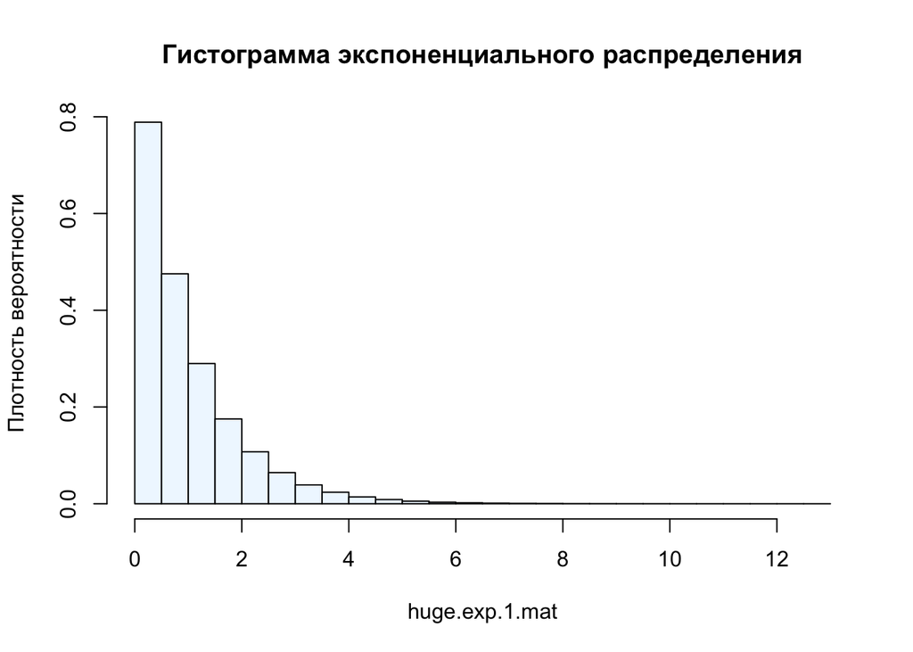

Гистограммы, полученные для векторов *huge.exp.1* и *huge.exp.1.mat* одинаковые.

5. Рассчитано среднее 137-й колонки из *huge.exp.1.mat*.

```
## [1] 0.9964764
```

6. Найдено среднее всех 1000 колонки и сохранено в вектор.

Отображена диаграмма средних значений колонок.

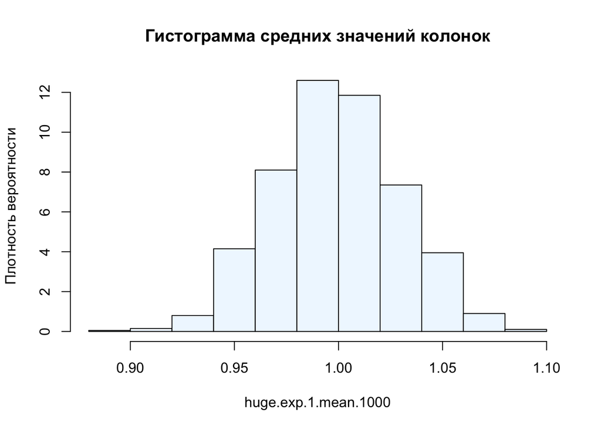

В данном случае на гистограмме изображена плотность вероятности от средних значений. Среднее значение экспоненциального распределения расчитывается по формуле: 1/λ. Для стандартного распределения λ = 1, поэтому среднее значение стремится к 1.

7. Расчитан квадрат каждого значения из *huge.exp.1* и найдено среднее и стандартное отклонение полученного вектора квадратов.

```
## [1] 4.452786
```

```
## [1] 1.995597
```